# Lab 12 Activity

Author

Published

Invalid Date

### Activity Objectives:

- Correlation
- Simple Regression

### Instructions:

- Fill in the code chunks
- Render the Quarto document and submit both the `.qmd` and `.html` file on Canvas

## Activity

### 1) If you’d like to load packages with `library()`, please do so in this block. Please install and load the `NHANES` package. We are going to use the `NHANES` dataset within the `NHANES` package today. This is a real survey dataset collected by the US National Center for Health Statistics (NCHS) called the National Health and Nutrition Examination Survey.

```r
# install.packages("NHANES")
library(tidyverse)
library(NHANES)
```

### 2) Read in the data and use a few functions to explore it.

```r
glimpse(NHANES)
```

```
Rows: 10,000
Columns: 77
$ ID               <int> 51624, 51624, 51624, 51625, 51630, 51638, 51646, 5164…
$ SurveyYr         <fct> 2009_10, 2009_10, 2009_10, 2009_10, 2009_10, 2009_10,…
$ Sex              <fct> male, male, male, male, female, male, male, female, f…
$ SexOrientation   <fct> Heterosexual, Heterosexual, Heterosexual, NA, Heteros…
$ Age              <int> 34, 34, 34, 4, 49, 9, 8, 45, 45, 45, 66, 58, 54, 10, …
$ AgeDecade        <fct>  30-39,  30-39,  30-39,  0-9,  40-49,  0-9,  0-9,  40…
$ AgeMonths        <int> 409, 409, 409, 49, 596, 115, 101, 541, 541, 541, 795,…
$ Race1            <fct> White, White, White, Other, White, White, White, Whit…
$ Race3            <fct> NA, NA, NA, NA, NA, NA, NA, NA, NA, NA, NA, NA, NA, N…
$ Education        <fct> High School, High School, High School, NA, Some Colle…
$ MaritalStatus    <fct> Married, Married, Married, NA, LivePartner, NA, NA, M…
$ HHIncome         <fct> 25000-34999, 25000-34999, 25000-34999, 20000-24999, 3…
$ HHIncomeMid      <int> 30000, 30000, 30000, 22500, 40000, 87500, 60000, 8750…
```

[output cut: 64 more lines]

### 3) This dataset contains a variable on the number of days someone experience bad physical health (`DaysPhysHlthBad`) and the number of days someone experience bad mental health (`DaysMentHlthBad`). Calculate the correlation between these two variables.

```r
cor(NHANES$DaysPhysHlthBad, NHANES$DaysMentHlthBad, use = "complete.obs")
```

```
[1] 0.2360289
```

### 4) Conduct a regression analysis on the effect of bad physical health days on bad mental health days. Print the summary and provide a brief interpretation (1–2 sentences).

```r
m <- lm(DaysMentHlthBad ~ DaysPhysHlthBad, data = NHANES)
summary(m)
```

```
Call:
lm(formula = DaysMentHlthBad ~ DaysPhysHlthBad, data = NHANES)

Residuals:
     Min       1Q   Median       3Q      Max
-10.7898  -3.2947  -3.2947  -0.0437  26.7053

Coefficients:
                Estimate Std. Error t value Pr(>|t|)
(Intercept)      3.29466    0.09624   34.23   <2e-16 ***
DaysPhysHlthBad  0.24984    0.01186   21.07   <2e-16 ***
---
Signif. codes:  0 '***' 0.001 '**' 0.01 '*' 0.05 '.' 0.1 ' ' 1

Residual standard error: 7.614 on 7528 degrees of freedom
  (2470 observations deleted due to missingness)
Multiple R-squared:  0.05571,   Adjusted R-squared:  0.05558
F-statistic: 444.1 on 1 and 7528 DF,  p-value: < 2.2e-16
```

### 5) Explain the relationship between the results of (3) and (4).

### 6) Test the correlation between the variable age (`Age`) and Systolic Blood Pressure (`BPSysAve`).

```r
cor.test(NHANES$Age, NHANES$BPSysAve)
```

```
    Pearson's product-moment correlation

data:  NHANES$Age and NHANES$BPSysAve
t = 55.423, df = 8549, p-value < 2.2e-16
alternative hypothesis: true correlation is not equal to 0
95 percent confidence interval:
 0.4983637 0.5295538
sample estimates:
      cor
0.5141287
```

### 7) Create a correlation matrix for the variables age (`Age`), hours of sleep at night (`SleepHrsNight`), pulse (`Pulse`), and total Cholesterol (`TotChol`) twice: once using only rows that don’t contain missing data, and once using rows that don’t contain missing data just for the pair of variables used in calculating the correlation. Compare the two correlation matrices. Which would you prefer to use in an analysis?

```r
NHANES |>
  select(Age, SleepHrsNight, Pulse, TotChol) |>
  cor(use = "complete.obs")
```

```
                        Age SleepHrsNight        Pulse     TotChol
Age            1.0000000000  0.0001689606 -0.160415001  0.20127216
SleepHrsNight  0.0001689606  1.0000000000  0.004943007 -0.01256309
Pulse         -0.1604150012  0.0049430069  1.000000000  0.05155411
TotChol        0.2012721624 -0.0125630915  0.051554109  1.00000000
```

```r
NHANES |>
  select(Age, SleepHrsNight, Pulse, TotChol) |>
  cor(use = "pairwise.complete.obs")
```

```
                       Age SleepHrsNight        Pulse      TotChol
Age            1.000000000  -0.005568086 -0.231207860  0.328618829
SleepHrsNight -0.005568086   1.000000000  0.006401566 -0.012246780
Pulse         -0.231207860   0.006401566  1.000000000 -0.001410612
TotChol        0.328618829  -0.012246780 -0.001410612  1.000000000
```

### 8) With the previous set of variables, create a scatterplot matrix visualization.

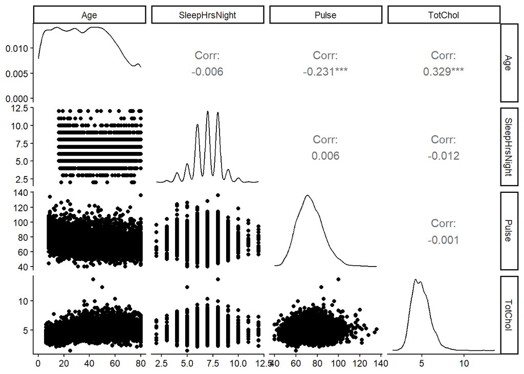

```r
NHANES |>
  select(Age, SleepHrsNight, Pulse, TotChol) |>
  GGally::ggpairs() +
  theme_classic()
```

### 9) As an exercise, calculate the $R^2$ value from the model in (4) “by hand” (i.e., without using the `summary()$r.squared` method). Hint: the `residuals(lm_model)` function will calculate the residual for each observation. Feel free to check your answer with `summary()$r.squared` Second hint: you may see slight differences from `lm()` having removed datapoints that had missingness on the predictor variable. If your two $R^2$ values are within 0.001 of each other, that’s fine. Alternatively, you can calculate the $R^2$ on a version of the NHANES dataset that removes `NA`s on both the predictor and outcome variables. If you do this, they should match exactly.

```r
d_cl <- NHANES |>
  select(DaysMentHlthBad, DaysPhysHlthBad) |>
  drop_na()

m <- lm(DaysMentHlthBad ~ DaysPhysHlthBad, data = NHANES)

var_y <- (d_cl$DaysMentHlthBad - mean(d_cl$DaysMentHlthBad))^2 |>
  sum(na.rm = T)

var_resid <- (residuals(m))^2 |>
  sum()

1 - (var_resid / var_y)
```

```
[1] 0.05570963
```

```r
summary(m)$r.squared
```

```
[1] 0.05570963
```

```r
sum((predict(m) - mean(d_cl$DaysMentHlthBad))^2) / var_y
```

```
[1] 0.05570963
```